# Example project

Last update: 2021-07-16 05:36:16

## Chunks

- `echo`: logical (TRUE/FALSE)
- `eval`: logical (TRUE/FALSE)
- `include`: logical (TRUE/FALSE)

```r
dat <- read_csv(here("data", "simulated_data.csv"))
```

## Plots

Important chunk options

- `fig.retina`: numeric (1 or 2)
- `fig.width`: numeric
- `fig.height`: numeric
- `fig.align`: character (‘left,’ ‘right,’ ‘center’)

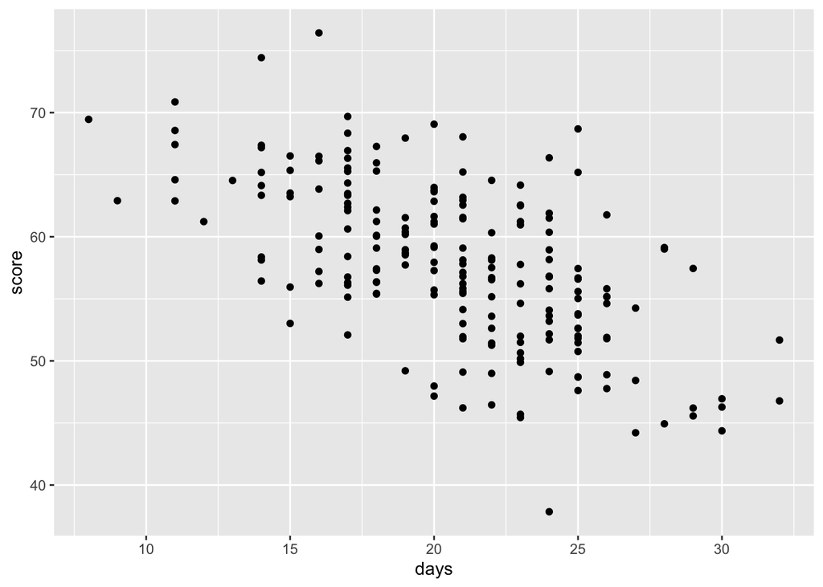

```r
dat %>%
  ggplot() +
  aes(x = days, y = score) +
    geom_point()
```

## Tables

Important chunk options

- `results`: character (‘hide,’ ‘asis’)

### Descriptive stats

```r
dat %>%
  summarize(n = n(), avg_score = mean(score), sd_score = sd(score)) %>%
  mutate_if(is.numeric, round, digits = 2) %>%
  kable(format = "pandoc")
```

| n | avg_score | sd_score |
| --- | --- | --- |
| 200 | 57.79 | 6.52 |

### Fit a model

```r
# Score as a function of days without sleep
mod <- lm(score ~ days, data = dat)

# Model summary
summary(mod)
```

```
##
## Call:
## lm(formula = score ~ days, data = dat)
##
## Residuals:
##      Min       1Q   Median       3Q      Max
## -16.9936  -3.7448  -0.0837   3.3398  14.7360
##
## Coefficients:
##             Estimate Std. Error t value Pr(>|t|)
## (Intercept) 76.25144    1.74513   43.69   <2e-16 ***
## days        -0.89199    0.08244  -10.82   <2e-16 ***
## ---
## Signif. codes:  0 '***' 0.001 '**' 0.01 '*' 0.05 '.' 0.1 ' ' 1
##
## Residual standard error: 5.184 on 198 degrees of freedom
## Multiple R-squared:  0.3715, Adjusted R-squared:  0.3684
## F-statistic: 117.1 on 1 and 198 DF,  p-value: < 2.2e-16
```

```r
# Assign to tidy object for cleaner printing
mod_tib <- tidy(mod) %>%
  mutate_if(is.numeric, round, digits = 2)
```

```r
mod_tib %>%
  kable(format = "pandoc")
```

| term | estimate | std.error | statistic | p.value |
| --- | --- | --- | --- | --- |
| (Intercept) | 76.25 | 1.75 | 43.69 | 0 |
| days | -0.89 | 0.08 | -10.82 | 0 |

```r
sjPlot::tab_model(mod)
```

## Writing results

We analyzed the simulated data using linear regression. The outcome variable, `score` was modeled as a function of days without sleep. The model estimate for the intercept was 76.25 ±1.75 standard errors (*t* = 43.69, p < .001). Scores decreased as days without sleep increased. Specifically, for each day without sleep scores decreased by -0.89 ± 0.08 standard errors (*t* = -10.82, p < .001).

There are also interesting helper packages that help automate reporting results in prose. See [academicWriteR](https://www.jvcasillas.com/academicWriteR/) and [report](https://easystats.github.io/report/).

```r
# You probably need to install first (only once)
if(F) {
  install.packages("report")
}

library(report)
report(mod)
```

## Different outputs

We can change the `output:` argument of the YAML front matter. Try `output: word_document` and `output: pdf_document` (if you have LaTeX installed). We can also change the style of the documents using CSS (see output options).

## Ref sections

You can use `.bib` files to automate reference sections.

Add this to the YAML front matter:

```
bib: r-references.bib
```

And then cite anything in the r-references.bib file using @ and the ref name. For example, we did our analysis in R (R Core Team, 2021). References don’t have to be parenthetical.  
Aust & Barth (2020) was used for APA formatting.

You can set the bibliography style using csl. For example:

```
csl: apa.csl
```

You can find an enormous list of csl classes [here](https://github.com/citation-style-language/styles). For more information about APA formatting with `papaja`, see the `example_apa.Rmd` file.

# References

Aust, F., & Barth, M. (2020). *papaja: Create APA manuscripts with R Markdown*. https://github.com/crsh/papaja

R Core Team. (2021). *R: A language and environment for statistical computing*. R Foundation for Statistical Computing. https://www.R-project.org/